# Integrantes do Projeto

# Técnicas de Balanceamento de Dados: Undersampling vs. Oversampling

## Undersampling

Under Sampling envolve reduzir o número de instâncias da classe majoritária para igualar o número da classe minoritária. Esta técnica é útil para reduzir o tempo de treinamento e lidar com grandes volumes de dados. No entanto, under sampling pode resultar na perda de informações importantes, já que dados potencialmente úteis são descartados.

### Métodos Comuns de Undersampling

- **Random Under Sampling**: Elimina aleatoriamente instâncias da classe majoritária.
- **Tomek Links**: Remove instâncias da classe majoritária que estão próximas a instâncias da classe minoritária, ajudando a definir um limite mais claro entre as classes.
- **ENN (Edited Nearest Neighbors)**: Elimina qualquer instância da classe majoritária cujos vizinhos mais próximos são majoritariamente da classe minoritária.
- **RENN (Repeated ENN)**: Aplica repetidamente ENN para remover mais instâncias, potencialmente resultando em um conjunto de dados mais limpo.

## Oversampling

Over Sampling aumenta o número de instâncias da classe minoritária criando cópias ou instâncias sintéticas, com o objetivo de alcançar um equilíbrio entre as classes. Essa técnica é eficaz para evitar a perda de informações importantes, mas pode levar ao overfitting, pois o modelo pode acabar aprendendo o ruído nos dados.

### Métodos Comuns de Oversampling

- **Random Over Sampling**: Replica aleatoriamente instâncias da classe minoritária.
- **SMOTE (Synthetic Minority Over-sampling Technique)**: Gera instâncias sintéticas da classe minoritária, utilizando uma interpolação entre instâncias existentes.
- **Borderline SMOTE**: Uma variação do SMOTE que foca na geração de instâncias sintéticas ao longo das fronteiras de decisão, onde os exemplos da classe minoritária estão mais propensos a serem confundidos com a classe majoritária.

## Combinação entre Over e Undersampling

É a combinação dos dois métodos acima para lidar com conjuntos de dados desbalanceados. Esse método se baseia em aplicar o oversampling na classe minoritária e, em seguida, aplicar o undersampling na classe majoritária para obter um conjunto de dados mais equilibrado. Ao combinar os dois métodos, é importante ajustar as proporções de oversampling e undersampling para evitar super ou sub-ajustes.

### Métodos Comuns de Combinação

- **SMOTEENN**: Combina SMOTE e ENN para um efeito mais robusto, aplicando over sampling com SMOTE e depois limpando os dados com ENN.
- **SMOTE + Tomek Links**: Combinação do SMOTE com o Tomek Links. O SMOTE cria exemplos sintéticos da classe minoritária, enquanto Tomek Links remove exemplos próximos das classes majoritárias e minoritárias que podem ser confundidos.

## Conclusão

A escolha entre undersampling, oversampling ou a sua combinação depende da natureza do problema, do tamanho do dataset e da importância de preservar informações versus o risco de overfitting. Em muitos casos, uma combinação dessas técnicas pode ser o melhor caminho, utilizando métodos híbridos para maximizar o desempenho do modelo sem comprometer a qualidade dos dados.

Por esse motivo, resolvemos testar alguns métodos de cada tipo para entender qual se ajustaria melhor em nossa situação.

# Limpeza do dataset e criação de modelos de machine learning

## Limpeza do dataset e pré-processamento

```python
df = pd.read_csv('/content/drive/MyDrive/Colab Notebooks/Fraudulent_E-Commerce_Transaction_Data_2.csv')
```

Como as variáveis de endereço são categóricas e possuem muitos valores únicos, decidimos que iríamos excluí-las do dataset. Mas, pensando em extrair algum tipo de informação delas, criamos uma nova coluna no formato de uma flag, marcando se os endereços de entrega e cobrança eram iguais ou não.

```python
df['Same Shipping-Billing Address'] = (df['Shipping Address'] == df['Billing Address']).astype(int)
```

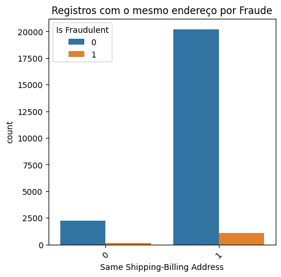

```python
plt.figure(figsize=(5, 5))

sns.countplot(x='Same Shipping-Billing Address', hue='Is Fraudulent', data=df)
plt.title('Registros com o mesmo endereço por Fraude')
plt.xticks(rotation=45)

plt.show()
```

Decidimos excluir as variáveis categóricas com valores únicos (Transaction ID, Customer ID,IP Address) e as que possuem grande quantidade de categorias (Transaction Date, Shipping Address, Billing Address, Customer Location).

```python
df = df.drop(columns = ['Transaction ID', 'Customer ID','Transaction Date','Customer Location','IP Address','Shipping Address','Billing Address',])
```

Durante a nossa análise, descobrimos que existiam idades negativas e idades muito baxias. Investigando com cuidado vimos que não existia uma propoorção maior de fraude mnesses casos. Por achar que esses registros não faziam sentido dentro do dataset, decidimos excluir todas as linhas que continham idade menor que 16 anos.

```python
df = df.drop(df[df['Customer Age'] < 16].index)
```

Transformamos as variáveis categóricas que ficaram na base em variáveis dummies

```python
df = pd.get_dummies(df, drop_first=True, dtype = int)
```

```python
df.head()
```

|  | Transaction Amount | Quantity | Customer Age | Is Fraudulent | Account Age Days | Transaction Hour | Same Shipping-Billing Address | Payment Method_bank transfer | Payment Method_credit card | Payment Method_debit card | Product Category_electronics | Product Category_health & beauty | Product Category_home & garden | Product Category_toys & games | Device Used_mobile | Device Used_tablet |
| --- | --- | --- | --- | --- | --- | --- | --- | --- | --- | --- | --- | --- | --- | --- | --- | --- |
| 0 | 42.32 | 1 | 40 | 0 | 282 | 23 | 1 | 0 | 0 | 0 | 1 | 0 | 0 | 0 | 0 | 0 |
| 1 | 301.34 | 3 | 35 | 0 | 223 | 0 | 1 | 0 | 1 | 0 | 1 | 0 | 0 | 0 | 0 | 1 |
| 2 | 340.32 | 5 | 29 | 0 | 360 | 8 | 0 | 0 | 0 | 1 | 0 | 0 | 0 | 1 | 0 | 0 |
| 3 | 95.77 | 5 | 45 | 0 | 325 | 20 | 1 | 0 | 1 | 0 | 1 | 0 | 0 | 0 | 1 | 0 |
| 4 | 77.45 | 5 | 42 | 0 | 116 | 15 | 1 | 0 | 1 | 0 | 0 | 0 | 0 | 0 | 0 | 0 |

```python
X = df.drop('Is Fraudulent', axis=1)
y = df['Is Fraudulent']
```

```python
X_train, X_test, y_train, y_test = train_test_split(X, y, test_size=0.2, random_state=42, stratify=y)
```

## Modelos de Machine Learning

Após fazer diversos testes com vários tipos de estimadores, técnicas de over e undersamplig e técnicas de seleção de hiperparâmetros, decidimos mostrar 5 modelos e seus resultados.

### Modelo I:

- **Escalonador:** StandardScaler
- **Oversampling:** BorderlineSMOTE
- **Estimador:** AdaBoostClassifier
- **Identificação de melhores hiperparâmetros:** GridSearch

Como temos uma base bem desbalanceada, decidimos fazer o primeiro teste usando a técnica de oversampling BoderlineSMOTE, que gera exemplos sintéticos focando apenas nas cocorrências da classe minoritária que estão próximas da fronteira de decisão.

Como estimador escolhemos o AdaBoostClassifier que apesar de não ter sido criada especificamente para bases desbalanceadas tem uma boa capacidade de concentrar em exemplos difíceis durante o treinamento, podendo melhorar o desempenho nesses casos.

Para a identificação dos melhores parâmetros nesse modelo usamos o GridSearch, para fazer algumas combinações entre os parêmtros de número de estimadores, taxa de aprendizagem para o estimador e a quantidade de vizinhos para o BoderlineSMOTE

```python
pipeline = ImPipeline([
    ('scaler', StandardScaler()),
    ('smote', BorderlineSMOTE(random_state=42, kind='borderline-1')),
    ('adaboost', AdaBoostClassifier(
        estimator=DecisionTreeClassifier(max_depth=1),
        n_estimators=100,
        learning_rate=1.0,
        random_state=42
    ))
])


cv_strategy = KFold(n_splits=5, shuffle=True, random_state=42)
scoring = {'Recall': make_scorer(recall_score), 'F1': make_scorer(f1_score)}

param_grid = {
    'adaboost__n_estimators': [50, 100, 150, 200],
    'adaboost__learning_rate': [0.5, 1.0, 1.5],
    'smote__k_neighbors': [5, 10, 15]
}

grid_search = GridSearchCV(pipeline, param_grid=param_grid, scoring=scoring, refit='F1', cv=cv_strategy, verbose=10)
grid_search.fit(X_train, y_train)
```

```
Melhores Parametros:

adaboost__learning_rate: 1.5
adaboost__n_estimators: 100
smote__k_neighbors: 5


Métricas de avaliação de treino:
```

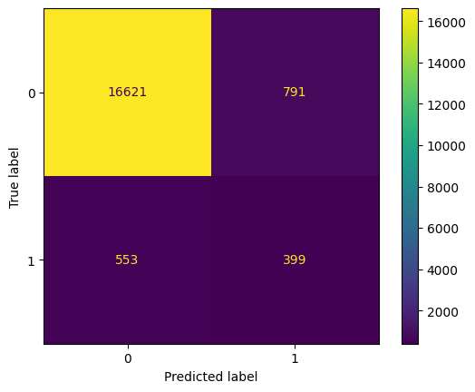

```
              precision    recall  f1-score   support

           0       0.97      0.95      0.96     17412
           1       0.34      0.42      0.37       952

    accuracy                           0.93     18364
   macro avg       0.65      0.69      0.67     18364
weighted avg       0.94      0.93      0.93     18364


Métricas de avaliação de teste:
```

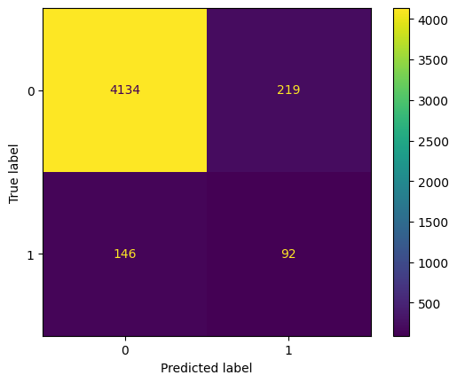

```
              precision    recall  f1-score   support

           0       0.97      0.95      0.96      4353
           1       0.30      0.39      0.34       238

    accuracy                           0.92      4591
   macro avg       0.63      0.67      0.65      4591
weighted avg       0.93      0.92      0.93      4591
```

```python
print('\nMelhores Parametros:')
print()

for chave, valor in grid_search.best_params_.items():
    print (f'{chave}: {valor}')
print()
print("\nMétricas de avaliação de treino:")

y_pred_train = grid_search.predict(X_train)

ConfusionMatrixDisplay.from_predictions(y_train, y_pred_train)
plt.show()

print(classification_report(y_train, y_pred_train))


# ============================================

print("\nMétricas de avaliação de teste:")

y_pred_test = grid_search.predict(X_test)

ConfusionMatrixDisplay.from_predictions(y_test, y_pred_test)
plt.show()

print(classification_report(y_test, y_pred_test))
```

**Conclusões:**

- Não ocorreu overfitting
- Métricas para a não ocorrência de fraude (0) estão ótimas tanto no treino quanto no teste
- Métricas para a ocorrência de fraude (1) não ficaram boas tanto no treino quanto no teste, chegando no máximo a aproximadamente 40%

### Modelo II:

- **Escalonador:** StandardScaler
- **Oversampling:** SMOTE
- **Estimadores:** RandomForestClassifier e AdaBoost
- **Identificação de melhores hiperparâmetros:** RandomizedSearch

Diferentemente do modelo anterior, nesse utilizamos o SMOTE, que ao invés de focar apenas nas classes minoritárias perto da fronteira de decisão, gera exemplos sintéticos de forma aleatória.

Com essa configuração de sampler testamos os estimadores AdaBoostClassifier e RandomForestClassifier, este último combina várias árvores de decisão e pode melhorar a generalização e a capacidade de lidar com classes minoritárias.

Para a identificação dos melhores parâmetros nesse modelo usamos o RandomizedSearch, para fazer testes com alguns parâmetros dos classificadores como número de estimadores e taxa de aprendizagem. Como a base é bem grande e queríamos testar deiversos parâmetros preferimos utilizar este ao invés do Grid por questão de tempo de processamento.

```python
pipe = ImPipeline([
    ('smote', SMOTE(random_state=42)),
    ('scaler', StandardScaler()),
    ('classifier', RandomForestClassifier(random_state=42))
])

metricas = {'recall': make_scorer(recall_score), 'f1': make_scorer(f1_score)}

cv_strategy = KFold(n_splits=5, shuffle=True, random_state=42)

param_grid_rf = {
    'classifier': [RandomForestClassifier(random_state=42)],
    'classifier__n_estimators': [40, 200, 20],
    'classifier__max_depth': [None, 10, 20],
    'classifier__max_features': ['log2', 'sqrt'],
    'classifier__criterion': ['gini', 'entropy']
}

param_grid_ab = {
    'classifier': [AdaBoostClassifier(estimator=DecisionTreeClassifier(max_depth=1), random_state=42)],
    'classifier__n_estimators': [40, 200, 20],
    'classifier__learning_rate': [0.5, 1.0, 1.5]
}

param_grid_combined = param_grid_rf.copy()
param_grid_combined.update(param_grid_ab)

grid_search_rf = RandomizedSearchCV(
    pipe,
    param_distributions=param_grid_rf,
    scoring={'recall': make_scorer(recall_score), 'f1': make_scorer(f1_score)},
    refit='f1',
    cv=cv_strategy,
    verbose=10,
    n_jobs = -1)
grid_search_rf.fit(X_train, y_train)

grid_search_ab = RandomizedSearchCV(
    pipe,
    param_distributions=param_grid_ab,
    scoring={'recall': make_scorer(recall_score), 'f1': make_scorer(f1_score)},
    refit='f1',
    cv=cv_strategy,
    verbose=10,
    n_jobs = -1)
grid_search_ab.fit(X_train, y_train)
```

```
Fitting 5 folds for each of 10 candidates, totalling 50 fits
```

```
Fitting 5 folds for each of 9 candidates, totalling 45 fits
```

```
RandomizedSearchCV(cv=KFold(n_splits=5, random_state=42, shuffle=True),
                   estimator=Pipeline(steps=[('smote', SMOTE(random_state=42)),
                                             ('scaler', StandardScaler()),
                                             ('classifier',
                                              RandomForestClassifier(random_state=42))]),
                   n_jobs=-1,
                   param_distributions={'classifier': [AdaBoostClassifier(estimator=DecisionTreeClassifier(max_depth=1),
                                                                          learning_rate=0.5,
                                                                          n_estimators=20,
                                                                          random_state=42)],
                                        'classifier__learning_rate': [0.5, 1.0,
                                                                      1.5],
                                        'classifier__n_estimators': [40, 200,
                                                                     20]},
                   refit='f1',
                   scoring={'f1': make_scorer(f1_score),
                            'recall': make_scorer(recall_score)},
                   verbose=10)
```

#### Resultados RandomForest

```
Melhores Parametros:

classifier__n_estimators: 40
classifier__max_features: sqrt
classifier__max_depth: 10
classifier__criterion: gini
classifier: RandomForestClassifier(max_depth=10, n_estimators=40, random_state=42)


Métricas de avaliação de treino:
```

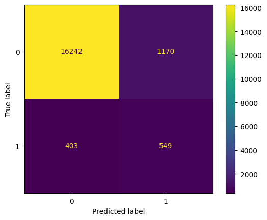

```
              precision    recall  f1-score   support

           0       0.98      0.93      0.95     17412
           1       0.32      0.58      0.41       952

    accuracy                           0.91     18364
   macro avg       0.65      0.75      0.68     18364
weighted avg       0.94      0.91      0.93     18364


Métricas de avaliação de teste:
```

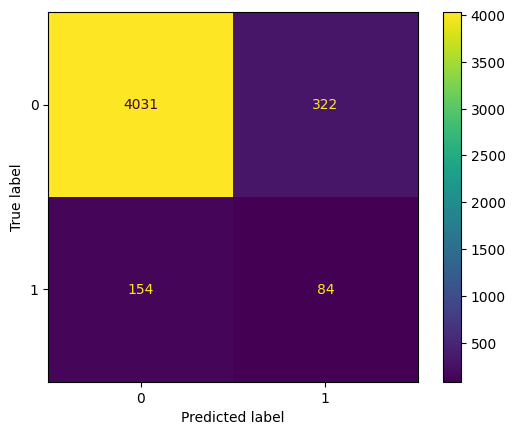

```
              precision    recall  f1-score   support

           0       0.96      0.93      0.94      4353
           1       0.21      0.35      0.26       238

    accuracy                           0.90      4591
   macro avg       0.59      0.64      0.60      4591
weighted avg       0.92      0.90      0.91      4591
```

```python
print('\nMelhores Parametros:')
print()

for chave, valor in grid_search_rf.best_params_.items():
    print (f'{chave}: {valor}')
print()
# ============================================

print("\nMétricas de avaliação de treino:")

y_pred_train = grid_search_rf.predict(X_train)

ConfusionMatrixDisplay.from_predictions(y_train, y_pred_train)
plt.show()

print(classification_report(y_train, y_pred_train))


# ============================================

print("\nMétricas de avaliação de teste:")

y_pred_test = grid_search_rf.predict(X_test)

ConfusionMatrixDisplay.from_predictions(y_test, y_pred_test)
plt.show()

print(classification_report(y_test, y_pred_test))
```

**Conclusões:**

- Não ocorreu overfitting
- Métricas para a não ocorrência de fraude (0) estão ótimas tanto no treino quanto no teste
- Métricas para a ocorrência de fraude (1) não ficaram boas, no treino o recall chegou a quase 60%, mas no teste nenhuma das métricas chegou a 40%

#### Resultados AdaBoostClassifier

```
Melhores Parametros:

classifier__n_estimators: 20
classifier__learning_rate: 0.5
classifier: AdaBoostClassifier(estimator=DecisionTreeClassifier(max_depth=1),
                   learning_rate=0.5, n_estimators=20, random_state=42)


Métricas de avaliação de treino:
```

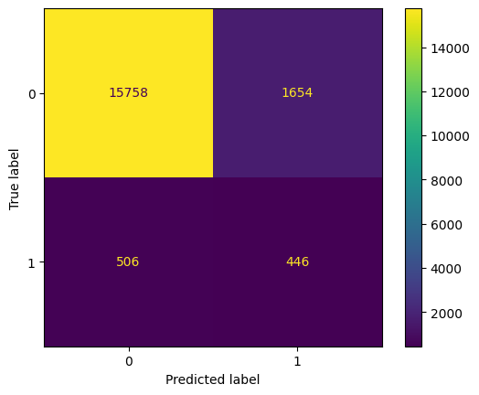

```
              precision    recall  f1-score   support

           0       0.97      0.91      0.94     17412
           1       0.21      0.47      0.29       952

    accuracy                           0.88     18364
   macro avg       0.59      0.69      0.61     18364
weighted avg       0.93      0.88      0.90     18364


Métricas de avaliação de teste:
```

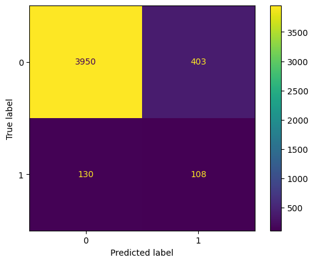

```
              precision    recall  f1-score   support

           0       0.97      0.91      0.94      4353
           1       0.21      0.45      0.29       238

    accuracy                           0.88      4591
   macro avg       0.59      0.68      0.61      4591
weighted avg       0.93      0.88      0.90      4591
```

```python
print('\nMelhores Parametros:')
print()

for chave, valor in grid_search_ab.best_params_.items():
    print (f'{chave}: {valor}')
print()
# ============================================

print("\nMétricas de avaliação de treino:")

y_pred_train = grid_search_ab.predict(X_train)

ConfusionMatrixDisplay.from_predictions(y_train, y_pred_train)
plt.show()

print(classification_report(y_train, y_pred_train))


# ============================================

print("\nMétricas de avaliação de teste:")

y_pred_test = grid_search_ab.predict(X_test)

ConfusionMatrixDisplay.from_predictions(y_test, y_pred_test)
plt.show()

print(classification_report(y_test, y_pred_test))
```

**Conclusões:**

- Não ocorreu overfitting
- Métricas para a não ocorrência de fraude (0) estão ótimas tanto no treino quanto no teste
- Métricas para a ocorrência de fraude (1) não ficaram boas. Apesar disso, diferente dos modelos anteriores, nesse o recall passou dos 40% tanto no treino como no teste. Mas a precision e o f1 permaneceram na casa dos 20%.

### Modelo III:

- **Escalonador:** StandardScaler
- **Combinação over e undersampling:** SMOTEENN
- **Estimador:** AdaBoostClassifier
- **Identificação de melhores hiperparâmetros:** RandomizedSearch

Nesse modelo resolvemos testar o método de combinação entre over e undersampling SMOTEENN. Essa técnica visa abordar o desbalanceamento quando há regiões de sobreposição entre as classes. Ela aproveita as vantagens da capacidade do SMOTE de gerar exemplos sintéticos e da capacidade do ENN de remover exemplos ruidosos.

```python
import pandas as pd
from sklearn.model_selection import train_test_split, GridSearchCV, StratifiedKFold, RandomizedSearchCV
from sklearn.ensemble import AdaBoostClassifier, RandomForestClassifier
from sklearn.preprocessing import StandardScaler
from sklearn.tree import DecisionTreeClassifier
from imblearn.over_sampling import SMOTE, BorderlineSMOTE
from imblearn.combine import SMOTEENN
from imblearn.under_sampling import EditedNearestNeighbours
from imblearn.pipeline import Pipeline as ImPipeline
from sklearn.metrics import recall_score, f1_score, make_scorer
import matplotlib.pyplot as plt
from sklearn.metrics import confusion_matrix, ConfusionMatrixDisplay
from sklearn.metrics import classification_report
from scipy.stats import randint, uniform
```

```python
pipe = ImPipeline([
    ('scaler', StandardScaler()),
    ('smote', SMOTEENN(enn=EditedNearestNeighbours(sampling_strategy='all'))),
    ('classifier', None)
])

metricas = {'recall': make_scorer(recall_score), 'f1': make_scorer(f1_score)}

param_distributions_ab = {
    'classifier': [AdaBoostClassifier(estimator=DecisionTreeClassifier(max_depth=1), random_state=42)],
    'classifier__n_estimators': randint(50, 200),
    'classifier__learning_rate': uniform(0.1, 1.5)
}

random_search_ab = RandomizedSearchCV(
    pipe, param_distributions=param_distributions_ab, n_iter=100, scoring=metricas, refit='f1', cv=KFold(n_splits=5, shuffle=True, random_state=42), verbose=10, random_state=42, n_jobs=-1
)
random_search_ab.fit(X_train, y_train)
```

```
Fitting 5 folds for each of 100 candidates, totalling 500 fits
```

```
RandomizedSearchCV(cv=KFold(n_splits=5, random_state=42, shuffle=True),
                   estimator=Pipeline(steps=[('scaler', StandardScaler()),
                                             ('smote',
                                              SMOTEENN(enn=EditedNearestNeighbours(sampling_strategy='all'))),
                                             ('classifier', None)]),
                   n_iter=100, n_jobs=-1,
                   param_distributions={'classifier': [AdaBoostClassifier(estimator=DecisionTreeClassifier(max_depth=1),
                                                                          learning_ra...
                                                                          n_estimators=188,
                                                                          random_state=42)],
                                        'classifier__learning_rate': <scipy.stats._distn_infrastructure.rv_continuous_frozen object at 0x7cc5fe3e62f0>,
                                        'classifier__n_estimators': <scipy.stats._distn_infrastructure.rv_discrete_frozen object at 0x7cc5fcfa4cd0>},
                   random_state=42, refit='f1',
                   scoring={'f1': make_scorer(f1_score),
                            'recall': make_scorer(recall_score)},
                   verbose=10)
```

```
Melhores Parametros:

classifier: AdaBoostClassifier(estimator=DecisionTreeClassifier(max_depth=1),
                   learning_rate=1.5751347113422645, n_estimators=188,
                   random_state=42)
classifier__learning_rate: 1.5751347113422645
classifier__n_estimators: 188


Métricas de avaliação de treino:
```

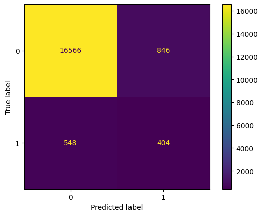

```
              precision    recall  f1-score   support

           0       0.97      0.95      0.96     17412
           1       0.32      0.42      0.37       952

    accuracy                           0.92     18364
   macro avg       0.65      0.69      0.66     18364
weighted avg       0.93      0.92      0.93     18364


Métricas de avaliação de teste:
```

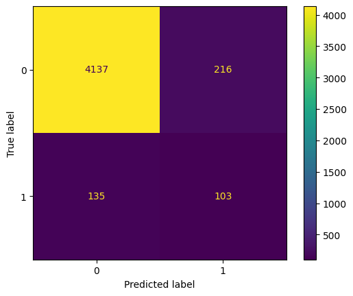

```
              precision    recall  f1-score   support

           0       0.97      0.95      0.96      4353
           1       0.32      0.43      0.37       238

    accuracy                           0.92      4591
   macro avg       0.65      0.69      0.66      4591
weighted avg       0.93      0.92      0.93      4591
```

```python
print('\nMelhores Parametros:')
print()

for chave, valor in random_search_ab.best_params_.items():
    print (f'{chave}: {valor}')
print()
# ============================================

print("\nMétricas de avaliação de treino:")

y_pred_train = random_search_ab.predict(X_train)

ConfusionMatrixDisplay.from_predictions(y_train, y_pred_train)
plt.show()

print(classification_report(y_train, y_pred_train))


# ============================================

print("\nMétricas de avaliação de teste:")

y_pred_test = random_search_ab.predict(X_test)

ConfusionMatrixDisplay.from_predictions(y_test, y_pred_test)
plt.show()

print(classification_report(y_test, y_pred_test))
```

**Conclusões:**

- Não ocorreu overfitting
- Métricas para a não ocorrência de fraude (0) estão ótimas tanto no treino quanto no teste
- Métricas para a ocorrência de fraude (1) não ficaram boas. O recall também passou dos 40% tanto no treino como no teste, mas diferente do modelo anterior, a precision e o f1 passaram dos 30%.

### Modelo IV:

- **Escalonador:** StandardScaler
- **Combinação over e undersampling:** SMOTEEEN
- **Estimador:** RandomForestClassifier
- **Identificação de melhores hiperparâmetros:** RandomizedSearch

```python
pipe = ImPipeline([
    ('scaler', StandardScaler()),
    ('smote', SMOTEENN(enn=EditedNearestNeighbours(sampling_strategy='all'))),
    ('classifier', None)
])

metricas = {'recall': make_scorer(recall_score), 'f1': make_scorer(f1_score)}

param_distributions_rf = {
    'classifier': [RandomForestClassifier(n_jobs= -1, random_state=42)],
    'classifier__n_estimators': randint(10, 100, 5),
    'classifier__max_depth': randint(2,10),
    'classifier__max_features': ['sqrt', 'log2', None],
    'classifier__min_samples_split': randint(2, 10),
    'classifier__min_samples_leaf': randint(1, 10),
    'classifier__criterion': ['gini', 'entropy']
}

random_search_rf = RandomizedSearchCV(
    pipe, param_distributions=param_distributions_rf, n_iter=100, scoring=metricas, refit='f1', cv=StratifiedKFold(n_splits=5, shuffle=True, random_state=42), verbose=10, random_state=42, n_jobs=-1
)
random_search_rf.fit(X_train, y_train)
```

```
Fitting 5 folds for each of 100 candidates, totalling 500 fits
```

```
RandomizedSearchCV(cv=StratifiedKFold(n_splits=5, random_state=42, shuffle=True),
                   estimator=Pipeline(steps=[('scaler', StandardScaler()),
                                             ('smote',
                                              SMOTEENN(enn=EditedNearestNeighbours(sampling_strategy='all'))),
                                             ('classifier', None)]),
                   n_iter=100, n_jobs=-1,
                   param_distributions={'classifier': [RandomForestClassifier(criterion='entropy',
                                                                              max_depth=9,
                                                                              max_feature...
                                        'classifier__min_samples_leaf': <scipy.stats._distn_infrastructure.rv_discrete_frozen object at 0x7cc5f1738820>,
                                        'classifier__min_samples_split': <scipy.stats._distn_infrastructure.rv_discrete_frozen object at 0x7cc5f17390f0>,
                                        'classifier__n_estimators': <scipy.stats._distn_infrastructure.rv_discrete_frozen object at 0x7cc5f151a3e0>},
                   random_state=42, refit='f1',
                   scoring={'f1': make_scorer(f1_score),
                            'recall': make_scorer(recall_score)},
                   verbose=10)
```

```
Melhores Parametros:

classifier: RandomForestClassifier(criterion='entropy', max_depth=9, max_features=None,
                       min_samples_leaf=4, min_samples_split=9, n_estimators=68,
                       n_jobs=-1, random_state=42)
classifier__criterion: entropy
classifier__max_depth: 9
classifier__max_features: None
classifier__min_samples_leaf: 4
classifier__min_samples_split: 9
classifier__n_estimators: 68


Métricas de avaliação de treino:
```

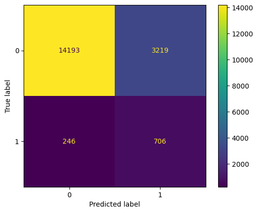

```
              precision    recall  f1-score   support

           0       0.98      0.82      0.89     17412
           1       0.18      0.74      0.29       952

    accuracy                           0.81     18364
   macro avg       0.58      0.78      0.59     18364
weighted avg       0.94      0.81      0.86     18364


Métricas de avaliação de teste:
```

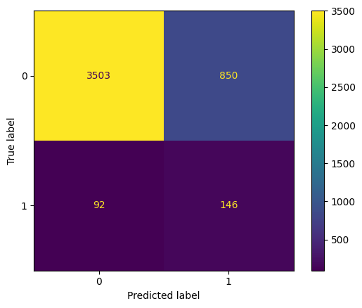

```
              precision    recall  f1-score   support

           0       0.97      0.80      0.88      4353
           1       0.15      0.61      0.24       238

    accuracy                           0.79      4591
   macro avg       0.56      0.71      0.56      4591
weighted avg       0.93      0.79      0.85      4591
```

```python
print('\nMelhores Parametros:')
print()

for chave, valor in random_search_rf.best_params_.items():
    print (f'{chave}: {valor}')
print()
# ============================================

print("\nMétricas de avaliação de treino:")

y_pred_train = random_search_rf.predict(X_train)

ConfusionMatrixDisplay.from_predictions(y_train, y_pred_train)
plt.show()

print(classification_report(y_train, y_pred_train))


# ============================================

print("\nMétricas de avaliação de teste:")

y_pred_test = random_search_rf.predict(X_test)

ConfusionMatrixDisplay.from_predictions(y_test, y_pred_test)
plt.show()

print(classification_report(y_test, y_pred_test))
```

**Conclusões:**

### Modelo V:

- **Escalonador:** MinMaxScaler
- **Oversampling:** SMOTEENN
- **Estimador:** Modelo KNN

```python
from sklearn.preprocessing import MinMaxScaler
from sklearn.model_selection import cross_val_score
from sklearn.neighbors import KNeighborsClassifier
from imblearn.combine import SMOTEENN
```

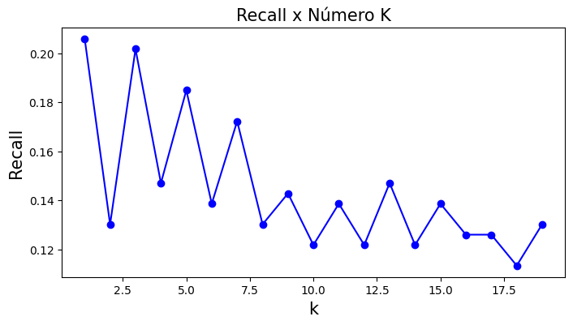

```
Melhor k: 1
```

```python
from sklearn.metrics import recall_score

ks = []
recalls = []
for k in range(1, 20):
    model = KNeighborsClassifier(n_neighbors=k)
    model.fit(X_train, y_train)
    y_pred = model.predict(X_test)
    rec = recall_score(y_test, y_pred, pos_label=1)
    recalls.append(rec)
    ks.append(k)

plt.figure(figsize=(8,4))
plt.plot(ks, recalls, '-bo')
plt.xlabel('k', fontsize = 15)
plt.ylabel('Recall', fontsize = 15)
plt.title('Recall x Número K', fontsize = 15)
plt.show(True)
best_k = np.argmax(recalls)+1
print('Melhor k:', best_k)
```

Apesar da análise acima indicar que o melhor número de vizinhos seria 1, resolvemos usar 3 vizinhos para evitar overfitting.

```python
pipe = ImPipeline([
    ('scaler', MinMaxScaler()),
    ('smoteenn', SMOTEENN(smote=SMOTE(k_neighbors=3), random_state=42)),
    ('minmax_scaler', MinMaxScaler()),
    ('classifier', KNeighborsClassifier(n_neighbors=3, weights='distance'))
])

cv_strategy = StratifiedKFold(n_splits=5, shuffle=True, random_state=42)

scores = cross_val_score(pipe, X_train, y_train, cv=cv_strategy, scoring='recall', n_jobs=-1)
```

```
Métricas de avaliação de treino:
```

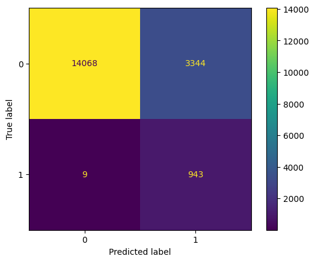

```
              precision    recall  f1-score   support

           0       1.00      0.81      0.89     17412
           1       0.22      0.99      0.36       952

    accuracy                           0.82     18364
   macro avg       0.61      0.90      0.63     18364
weighted avg       0.96      0.82      0.87     18364


Métricas de avaliação de teste:
```

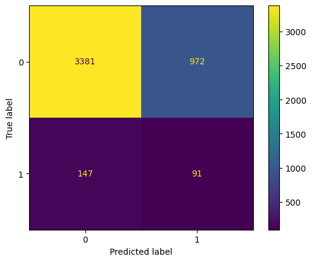

```
              precision    recall  f1-score   support

           0       0.96      0.78      0.86      4353
           1       0.09      0.38      0.14       238

    accuracy                           0.76      4591
   macro avg       0.52      0.58      0.50      4591
weighted avg       0.91      0.76      0.82      4591
```

```python
pipe.fit(X_train, y_train)

print("\nMétricas de avaliação de treino:")
y_pred_train = pipe.predict(X_train)
ConfusionMatrixDisplay.from_predictions(y_train, y_pred_train)
plt.show()
print(classification_report(y_train, y_pred_train))

print("\nMétricas de avaliação de teste:")
y_pred_test = pipe.predict(X_test)
ConfusionMatrixDisplay.from_predictions(y_test, y_pred_test)
plt.show()
print(classification_report(y_test, y_pred_test))
```

**Conclusões:**

- Provavelmente ocorreu overfitting, pois o resultado do treino ficou bem melhor do que o teste para as três métricas, principalmente no recall (99% x 38%)
- Não podemos considerar esse modelo.

### Escolha do melhor modelo

A métrica que decidimos avaliar foi o **recall**, pois o intuito desse projeto é deixar passar o mínimo de fraudes possível.

Após analisar os resultados de todos os modelos, decidimos que o melhor entre todos foi o **Modelo III** (SMOTEENN, AdaBoostClassifier, RandomizedSearchCV):

```
            precision    recall  f1-score   support

       0       0.97      0.95      0.96      4353
       1       0.32      0.43      0.37       238

accuracy                            0.92      4591
macro avg       0.65      0.69      0.66      4591
weighted avg    0.93      0.92      0.93      4591
```

Apesar de ter tido outros modelos com um recall maior, esse modelo se mostrou o melhor entre eles, pois a precisão não foi tão baixa. Isso porque também não é interessante ficar bloqueando as transações que na realidade são "honestas".

# Conclusão do Projeto

Após a aplicação e avaliação de diversos modelos de machine learning, bem como a implementação de várias técnicas de balanceamento de dados, os resultados obtidos indicaram desafios significativos relacionados às métricas de precisão e recall para a detecção de transações fraudulentas (categoria 1). Cabo ressaltar que Kafhali e Tayebi (2022) recomendam os seguintes valores para as métricas de acurácia, precisão, recall e F1-score, no contexto da previsão de fraudes em cartões de crédito:

- Acurácia: 99.94%.
- Precisão: 80.68%.
- Recall: 86.02%.
- F1-score: 83.27%

**Referência**: Kafhali, S.E., & Tayebi, M. (2022). XGBoost based solutions for detecting fraudulent credito card transactions. 2022 International Conference on Advanced Creative Networks and Intelligent Systems (ICACNIS), 1-6.

## Problemas Identificados

- **Baixa Precisão**: A precisão para a categoria de transações fraudulentas foi observada como sendo inadequadamente baixa. Uma precisão baixa implica que muitas transações legítimas seriam erroneamente classificadas como fraudulentas. Isso poderia resultar em inconvenientes significativos para os clientes, como bloqueios desnecessários de transações e a necessidade de verificações adicionais para esclarecer os erros de classificação.
- **Recall Insuficiente**: O recall, ou taxa de verdadeiros positivos, também se mostrou abaixo do limiar de 86.02% considerado aceitável para este projeto. Um recall abaixo de 86.02% significa que uma proporção considerável de transações fraudulentas não seria identificada pelo modelo. Isso não só resultaria em perdas financeiras devido à aprovação de transações fraudulentas, mas também poderia comprometer a confiança do usuário na plataforma de e-commerce.

## Implicações Técnicas

- **Precisão**: Métrica que indica a proporção de identificações positivas que foram realmente corretas. Baixa precisão em um contexto de detecção de fraude pode levar a um alto número de falsos positivos, ou seja, transações legítimas sendo bloqueadas como fraudulentas.
- **Recall**: Métrica que reflete a proporção de positivos reais que foram corretamente identificados pelo modelo. Em termos de detecção de fraude, um recall alto é crucial para garantir que a maioria das atividades fraudulentas seja detectada e tratada apropriadamente.

## Conclusão e Recomendações

Diante desses desafios, concluímos que o modelo atual ainda não está pronto para ser implementado em produção. É essencial melhorar as métricas de desempenho para garantir que o sistema de detecção de fraude seja tanto eficaz quanto eficiente. Recomendamos as seguintes ações para avançar no desenvolvimento do modelo:

1. **Coleta de Mais Dados**: Especificamente, dados adicionais sobre transações fraudulentas poderiam ajudar a melhorar o equilíbrio das classes no conjunto de dados, permitindo que o modelo aprenda características mais discriminativas de fraudes.
2. **Revisão das Técnicas de Balanceamento de Dados**: Explorar outras técnicas de balanceamento que possam fornecer melhores resultados para as características específicas do nosso dataset.
3. **Experimentação com Modelos Avançados**: Considerar o uso de técnicas de machine learning mais avançadas ou modelos híbridos que possam lidar de forma mais eficiente com o desbalanceamento e a complexidade dos dados.
4. **Aplicação de peso nas variáveis onde a propensão de fraude é maior**: Na análise foi encontrada uma maior concentração de transações fraudulentas prara certos intervalos nas features "Idade da conta" e "Hora da Transação". Sugere-se que pesos sejam reconsiderados para essas features em futuros modelos.

A implementação dessas melhorias é crucial para aumentar a precisão e o recall, minimizando o risco de perdas financeiras e maximizando a satisfação e segurança do usuário.